# Exploration of the factors that influenced students' math scores in PISA data

## Preliminary Wrangling

The original dataset is extremely large and difficult to read. Therefore, I decided to take out some interesting columns and formed a new csv file called "new_data" so I don't need to wait for loading every time I run the codes.

```python
# import all packages and set plots to be embedded inline
import numpy as np
import pandas as pd
import matplotlib.pyplot as plt
import seaborn as sb

%matplotlib inline
```

```python
# have a look at the original dataset
data = pd.read_csv('pisa2012.csv', encoding = 'latin-1')
```

```python
# create a dictionary of the columns I am interest
col_name = {'CNT':'Country','ST04Q01':'gender','ST15Q01':'mother_job_status',\
 'ST19Q01':'father_job_status','ST46Q07':'listen_in_class',\
 'ST77Q01':'teacher_show_interest','WEALTH':'wealth','TIMEINT':'time_of_computer_use','INTMAT':'mathematical_interest'}
```

```python
# create a new dataframe containing only these columns and rename them to something more intuitive
data = data.loc[:,['CNT','ST04Q01','ST15Q01','ST19Q01','ST46Q07','ST77Q01','WEALTH','TIMEINT','INTMAT','PV1MATH','PV2MATH','PV3MATH','PV4MATH','PV5MATH']]
data = data.rename(columns = col_name)

# I used the mean of five math values to stand for the students' math score
data['math_value'] = (data['PV1MATH']+data['PV2MATH']+data['PV3MATH']+data['PV4MATH']+data['PV5MATH'])/5
data = data.drop(columns = {'PV1MATH','PV2MATH','PV3MATH','PV4MATH','PV5MATH'}, axis = 1)
data.head()
```

|  | Country | gender | mother_job_status | father_job_status | listen_in_class | teacher_show_interest | wealth | time_of_computer_use | mathematical_interest | math_value |
| --- | --- | --- | --- | --- | --- | --- | --- | --- | --- | --- |
| 0 | Albania | Female | Other (e.g. home duties, retired) | Working part-time <for pay> | Agree | Every Lesson | -2.92 | NaN | 0.91 | 366.18634 |
| 1 | Albania | Female | Working full-time <for pay> | Working full-time <for pay> | Agree | NaN | 0.69 | NaN | 0.00 | 470.56396 |
| 2 | Albania | Female | Working full-time <for pay> | Working full-time <for pay> | Strongly agree | NaN | -0.23 | NaN | 1.23 | 505.53824 |
| 3 | Albania | Female | Working full-time <for pay> | Working full-time <for pay> | NaN | Every Lesson | -1.17 | NaN | NaN | 449.45476 |
| 4 | Albania | Female | Working part-time <for pay> | Working part-time <for pay> | Strongly agree | Every Lesson | -1.17 | NaN | 0.30 | 385.50398 |

```python
# save as a new csv file
data.to_csv('new_data',index = False)
```

```python
# load the new dataframe
df = pd.read_csv('new_data')
df.head()
```

|  | Country | gender | mother_job_status | father_job_status | listen_in_class | teacher_show_interest | wealth | time_of_computer_use | mathematical_interest | math_value |
| --- | --- | --- | --- | --- | --- | --- | --- | --- | --- | --- |
| 0 | Albania | Female | Other (e.g. home duties, retired) | Working part-time <for pay> | Agree | Every Lesson | -2.92 | NaN | 0.91 | 366.18634 |
| 1 | Albania | Female | Working full-time <for pay> | Working full-time <for pay> | Agree | NaN | 0.69 | NaN | 0.00 | 470.56396 |
| 2 | Albania | Female | Working full-time <for pay> | Working full-time <for pay> | Strongly agree | NaN | -0.23 | NaN | 1.23 | 505.53824 |
| 3 | Albania | Female | Working full-time <for pay> | Working full-time <for pay> | NaN | Every Lesson | -1.17 | NaN | NaN | 449.45476 |
| 4 | Albania | Female | Working part-time <for pay> | Working part-time <for pay> | Strongly agree | Every Lesson | -1.17 | NaN | 0.30 | 385.50398 |

```python
# check the statistics
print(df.dtypes)
print(df.shape)
```

```
Country                   object
gender                    object
mother_job_status         object
father_job_status         object
listen_in_class           object
teacher_show_interest     object
wealth                   float64
time_of_computer_use     float64
mathematical_interest    float64
math_value               float64
dtype: object
(485490, 10)
```

```python
# change some data types
#gender
df.gender = df.gender.astype('category')
# set 'job_status' as ordered categories
job = ['Working full-time <for pay>','Working part-time <for pay>','Not working, but looking for a job','Other (e.g. home duties, retired) ']
job_class =  pd.api.types.CategoricalDtype(ordered = True, categories = job)
df['mother_job_status'] =df['mother_job_status'].astype(job_class)
df['father_job_status'] = df['father_job_status'].astype(job_class)
# set 'teacher interes' as ordered categories
teacher_int = ['Every Lesson','Most Lessons','Some Lessons','Never or Hardly Ever']
teacher_int_class = pd.api.types.CategoricalDtype(ordered = True, categories = teacher_int)
df['teacher_show_interest'] = df['teacher_show_interest'].astype(teacher_int_class)
# set 'listen in class' as ordered categories
agree_list = ['Strongly agree','Agree','Disagree','Strongly disagree']
agree_class = pd.api.types.CategoricalDtype(ordered = True,categories = agree_list)
df['listen_in_class'] = df['listen_in_class'].astype(agree_class)
```

```python
# test
df.info()
```

```
<class 'pandas.core.frame.DataFrame'>
RangeIndex: 485490 entries, 0 to 485489
Data columns (total 10 columns):
Country                  485490 non-null object
gender                   485490 non-null category
mother_job_status        217078 non-null category
father_job_status        111713 non-null category
listen_in_class          312854 non-null category
teacher_show_interest    315248 non-null category
wealth                   479597 non-null float64
time_of_computer_use     297074 non-null float64
mathematical_interest    316708 non-null float64
math_value               485490 non-null float64
dtypes: category(5), float64(4), object(1)
memory usage: 20.8+ MB
```

### What is/are the main feature(s) of interest in your dataset?

I would like to find out what factors influence students' math scores most.

### What features in the dataset do you think will help support your investigation into your feature(s) of interest?

I would expect that mother and father's job status would have some impacts on children's education. But I'm not sure if math scores would be impacted specifically. Wealth should make some differences as well. I would love to find out whether there are relationships between the other factors and students' math grades.

## Univariate Exploration

Let's look at the variables individually. Let's start with math grades.

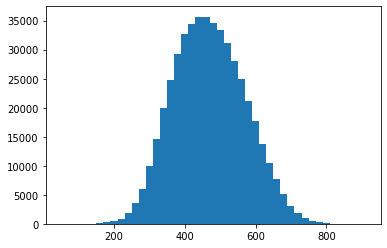

```python
bin_size = np.arange(50,df.math_value.max()+20,20 )
plt.hist(data = df, x ='math_value', bins = bin_size);
```

```python
df.math_value.max()
```

```
903.1079599999999
```

It looks like math scores are normally distributed.

Let's have a look at other numerical data.

```python
df.mathematical_interest.unique()
```

```
array([ 0.91,  0.  ,  1.23,   nan,  0.3 ,  2.29,  0.05, -0.78,  1.81,
        1.36,  1.51,  2.06,  0.58, -0.66,  0.87, -0.34,  1.76,  0.37,
       -0.95, -1.27, -1.78,  1.62,  0.84, -0.2 , -0.42,  1.09,  1.45,
       -1.75,  2.26,  0.49,  2.24, -0.41,  0.44,  1.73,  0.24, -0.77,
        0.92,  0.09, -1.49,  2.1 ,  1.06,  1.4 , -0.27,  1.26,  0.41,
       -0.36, -0.83,  1.28,  1.01,  1.55, -1.16,  1.65, -0.15, -1.1 ,
       -0.09,  0.99,  2.04,  0.2 , -1.  ,  1.98,  0.1 ,  2.17,  0.96,
        2.13, -0.38,  0.93, -0.79,  0.75,  0.88,  0.47, -1.21, -0.17,
        0.03, -1.73, -1.72, -1.18,  1.49,  0.17, -1.33, -1.41,  2.21,
       -0.25, -0.82,  1.5 , -1.02,  1.89, -0.69,  2.07, -1.2 , -0.5 ,
       -1.06, -0.86, -1.38, -1.68,  1.34, -0.46, -1.71])
```

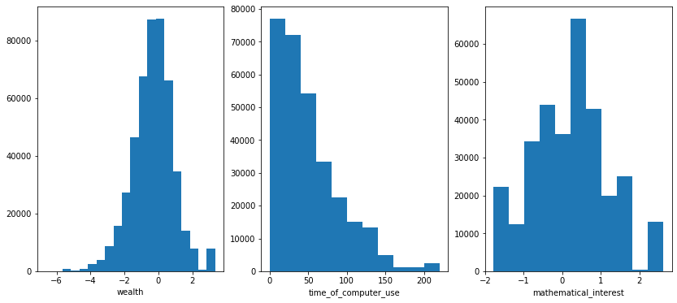

```python
plt.figure(figsize = [14,6])

# plot associated with "wealth"
plt.subplot(1,3,1)
bin_size = np.arange(df.wealth.min(),df.wealth.max()+0.5, 0.5 )
plt.hist(data = df, x = 'wealth', bins = bin_size)
plt.xlabel('wealth')

# plot associated with "time_of_computer_use"
plt.subplot(1,3,2)
bin_size = np.arange(df.time_of_computer_use.min(),df.time_of_computer_use.max()+20, 20)
plt.hist(data = df, x = 'time_of_computer_use',bins = bin_size)
plt.xlabel('time_of_computer_use')

# plot associated with "mathematical_interest"
plt.subplot(1,3,3)
bin_size = np.arange(df.mathematical_interest.min(),df.mathematical_interest.max()+0.4, 0.4)
plt.hist(data = df, x = 'mathematical_interest', bins = bin_size)
plt.xlabel('mathematical_interest')
```

From these graphs, we can see that the wealth graph is a little bit left-tailed, with most of people having close to 0 wealth and more people having less than 0 compared with those having wealth coefficient higher than 0. The graph of 'time of computer use' is very right-tailed, which indicates that most students had limited time to access computer. However, the scores for "mathematical interest" is has a noramlly distributed feature. The largest amount of students had a mathematical interest between 0 and 1.

Let's figure out how the categorical data are distributed.

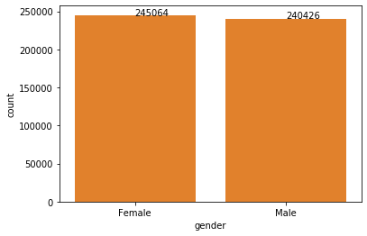

```python
# the gender
base_color = sb.color_palette()[1]
sb.countplot(data = df, x = 'gender', color = base_color)
plt.text(0,df.loc[df.gender=='Female'].shape[0]+1,df.loc[df.gender=='Female'].shape[0])
plt.text(1,df.loc[df.gender=='Male'].shape[0]+1,df.loc[df.gender=='Male'].shape[0])
```

The number of females and the number of males are very similar, which might give us fairer results.

Let's explore these two categorical columns together: "mother_job_status" and "father_job_status".

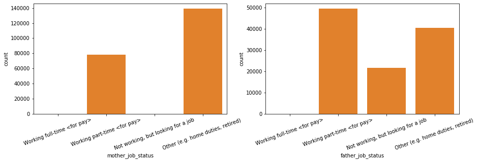

```python
plt.figure(figsize = [15,4])
base_color = sb.color_palette()[1]
plt.subplot(1,2,1)
sb.countplot(data = df, x ='mother_job_status' ,color = base_color)
plt.xticks(rotation = 20)
plt.subplot(1,2,2)
sb.countplot(data = df, x ='father_job_status' ,color = base_color)
plt.xticks(rotation = 20)
```

We are very surprised to see that none of the mothers or fathers are working full time for pay in our dataset. For students' mothers, none of them are not working but looking for a job. However, there are substential fathers who are in this status.

Let's explore these two categorical columns: "listen_in_class" and "teacher_show_interest".

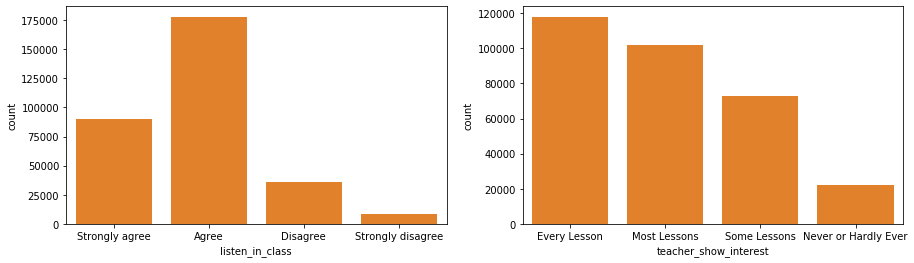

```python
plt.figure(figsize = [15,4])
base_color = sb.color_palette()[1]
plt.subplot(1,2,1)
sb.countplot(data = df, x ='listen_in_class' ,color = base_color)

plt.subplot(1,2,2)
sb.countplot(data = df, x ='teacher_show_interest' ,color = base_color)
```

Most of the students thought that they listened carefully in class. The next large number came from those who thought they strongly agree with this statement. From the right graph, the audience (whoever answered the questionaires) believed that teachers showed interest in class. The number of counts descended as the ordinal sequence goes to right.

Let's see what countries do the students live in, in majority.

```
66
```

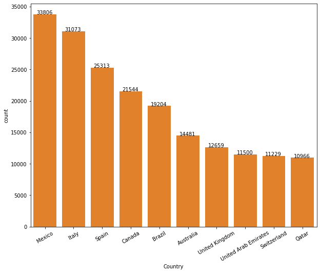

```python
country_list = df.Country.value_counts()[:10].index
plt.figure(figsize = [10,8])
sb.countplot(data = df, x = 'Country', order = country_list, color = base_color)
plt.xticks(rotation = 30)
for i in range(len(country_list)):
    plt.text(i-0.3,df.loc[df.Country== country_list[i]].shape[0]+1,df.loc[df.Country== country_list[i]].shape[0]);
print(df.Country.nunique())
```

Well, I don't see U.S. in here. Why is that? Let's see what unique countries there are.

```python
df.Country.unique()
```

[output not shown]

```python
df.Country = df.Country.replace('Florida (USA)','USA')
df.Country = df.Country.replace('Connecticut (USA)','USA')
df.Country = df.Country.replace('Massachusetts (USA)','USA')
```

Let's plot the graph for USA along with the top 10 countries to have a comparison.

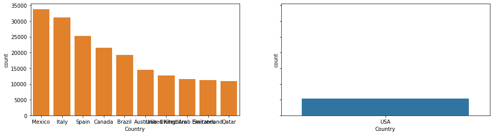

```python
f, (ax1, ax2) = plt.subplots(nrows = 1, ncols = 2, sharey = True,figsize = [16,4])

g = sb.countplot(data = df, x = 'Country', order = country_list, color = base_color, ax = ax1)




us = df.loc[df.Country =='USA']
sb.countplot(data = us, x = 'Country', ax = ax2);
```

Students from USA are still not a lot. Therefore, we should consider the results more as a global finding that means more to the countries on the left graph.

### Discuss the distribution(s) of your variable(s) of interest. Were there any unusual points? Did you need to perform any transformations?

We had some good distribution between numerical and categorical data in our data frame. The dependent variabel "math scores" had a normal distribution.

### Of the features you investigated, were there any unusual distributions? Did you perform any operations on the data to tidy, adjust, or change the form of the data? If so, why did you do this?

We didn't have to do any transformation in our graph. The only change we made to our data frame was to combine American cities together to represent USA in the data.

## Bivariate Exploration

Let's have a look at the general correlation first.

```python
numerical = ['math_value','wealth','time_of_computer_use','mathematical_interest']
categorical = ['gender', 'mother_job_status','father_job_status','listen_in_class','teacher_show_interest']
```

To speed up the process, I drew a sample with the sample size of 500 from the data.

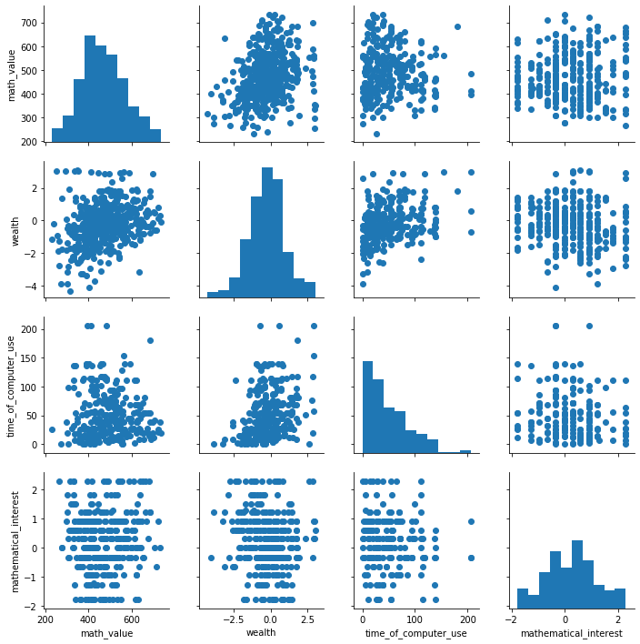

```python
sample = np.random.choice(df.shape[0], 500, replace = False )
sub = df.loc[sample,:]
g = sb.PairGrid(data = sub, vars = numerical)
g = g.map_diag(plt.hist)
g.map_offdiag(plt.scatter)
```

None of the graph showed clear correlation between each other. We need further exploration in this.

Let's produce a heatmap as well.

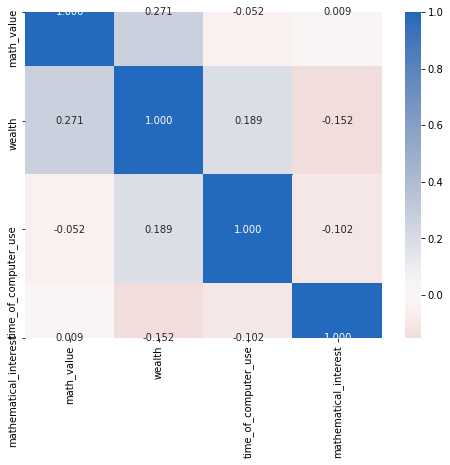

```python
plt.figure(figsize = [8, 6])
g = sb.heatmap(data[numerical].corr(),annot = True, fmt = '.3f',
           cmap = 'vlag_r', center = 0 )
g.set_yticklabels(rotation = 90, labels = numerical);
```

It's surprised to see that math scores had very very little (almost no) correlation with math interest. However, math scores had 0.271 correlation coeff with wealth. Wealth had 0.189 correlation coeff with time_of_computer_use.

Let's see how some numerical data relate with categorical data.

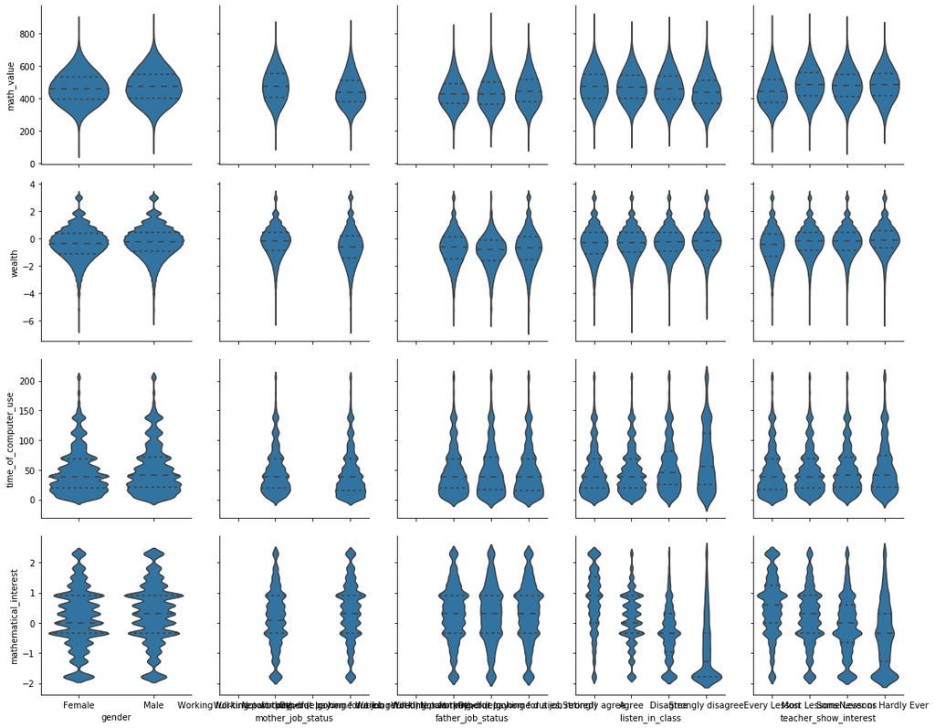

```python
def violinplot(x, y, **kwargs):
    base_color = sb.color_palette()[0]
    sb.violinplot(x, y, color =base_color, inner = 'quartile' )
g = sb.PairGrid(data = df, x_vars = categorical, y_vars = numerical, size =3)
g.map(violinplot);
```

A few findings from these violinplots are:

- There are almost no difference for any numerical data between females and males. Maybe we need to use other plot forms.
- Parents' job status has no impact as well.
- Students who believe that listening in class was not important generally had less mathmetical interest and performed slightly worse than students who listened in class.
- Teachers who showed most interest resulted in slighly worse math scores of students, and teachers who hardly ever showed interest led to less interest in students towards math as well.

We are going to focus our exploration on "listen_in_class" and "teacher_show_interest" factors.

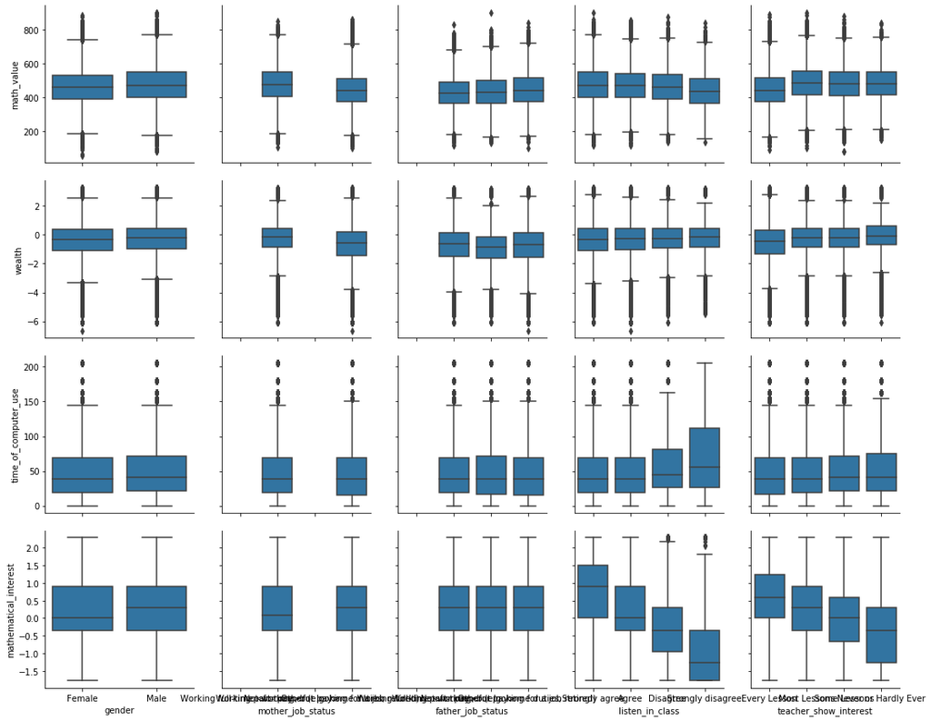

```python
def boxplot(x, y, **kwargs):
    base_color = sb.color_palette()[0]
    sb.boxplot(x, y, color =base_color )
g = sb.PairGrid(data = df, x_vars = categorical, y_vars = numerical, size =3)
g.map(boxplot);
```

The boxplots generated similar results as violinplots above, except that this time, the different results that "listen_in_class" and "teacher_show_interest" are more clear. Especially, the relationship between "listen_in_class"/"teacher_show_interest" and "mathematical interest" are more obvious. Also, we found that students who stronly disagree to listen in class had more time to use computer.

From the results so far, I am intersted to investigate further about the relationship between:

```
- gender vs. math scores
- gender vs. math interest
- math scores vs. time_of_computer_use
- math scores vs. wealth
- wealth vs. computer use
- listen_in_class vs. math_interest
- listen_in_class vs. time_of_computer_use
- teacher_interest vs. math_interest
- math scores vs. teacher_interest
```

Let's first see whether gender makes a difference in math scores and math interest.

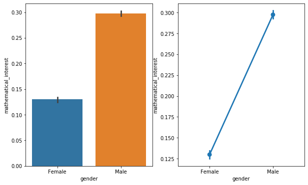

```python
fig, ax = plt.subplots(ncols = 2, figsize = [10,6])
sb.barplot(data = df, x = 'gender', y = 'mathematical_interest', ax = ax[0])
sb.pointplot(data = df, x = 'gender', y = 'mathematical_interest', ax = ax[1])
```

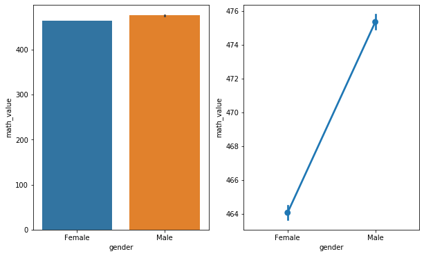

```python
fig, ax = plt.subplots(ncols = 2, figsize = [10,6])
sb.barplot(data = df, x = 'gender', y = 'math_value', ax = ax[0])
sb.pointplot(data = df, x = 'gender', y = 'math_value', ax = ax[1])
```

From the plots above, we can see that males generally had a better interest towards math and they tend to get higher math scores than females as well.

I will make a sub-dataframe with random samples to ease the plotting process below.

```python
sample = np.random.choice(df.shape[0],200, replace = False)
sub = df.loc[sample,:]
```

Let's see the relationship between time_of_computer_use and math_score using a smaller sample with a sample size of 200.

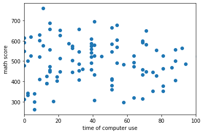

```python
plt.scatter(data = sub, x = 'time_of_computer_use', y = 'math_value')
plt.xlim(0,100)
plt.xlabel('time of computer use')
plt.ylabel('math score')
```

We can observe that students spending less time using computer had a higher chance to achieve a better math score. But the relationship is not clear.

Let's create a scatter plot between wealth and math_score using a smaller sample size.

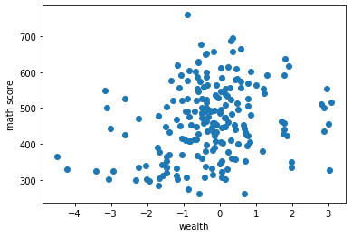

```python
plt.scatter(data = sub, x = 'wealth', y = 'math_value')

plt.xlabel('wealth')
plt.ylabel('math score')
```

We can see that the middle parts involved the most data, and high-score points happened to land in the middle range on the wealth axis as well. The relationship is still not very clear.

Let's see the scatter plot between wealth and time_of_computer_use.

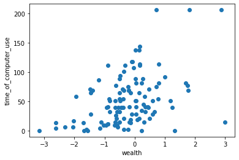

```python
plt.scatter(data = sub, x = 'wealth', y = 'time_of_computer_use')

plt.xlabel('wealth')
plt.ylabel('time_of_computer_use')
```

It's clear to see that less wealthy students use less computer and more wealthy students use more computer. There is no clear relationship for the middle range wealth students.

However, based on these bivariate plots between these three factors: "time_of_computer_use", "wealth", and "math scores", the relationship between each two of three is not extremely obvious and clear.

Next, let's see the relationship between categorical and numerical data. I decided to use point plots to amplify the differences.

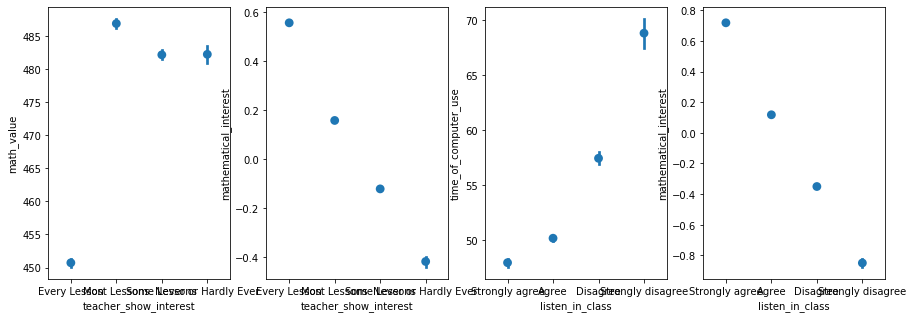

```python
fig, ax = plt.subplots(nrows = 1, ncols = 4, figsize = [15,5])
sb.pointplot(data = df, x = 'teacher_show_interest', y = 'math_value', linestyles = '', ax = ax[0])
sb.pointplot(data = df, x = 'teacher_show_interest', y = 'mathematical_interest', linestyles = '', ax = ax[1])
sb.pointplot(data = df, x = 'listen_in_class', y = 'time_of_computer_use', linestyles = '', ax = ax[2])
sb.pointplot(data = df, x = 'listen_in_class', y = 'mathematical_interest', linestyles = '', ax = ax[3])
```

We can conclude that teachers who showed interest in every lesson led to a lower average math scores but they enhanced students' interest towards math. However, teacher who showed interest in most lessons helped students get the highest math scores. On the other hand, studnents who strongly agreed that listening in class is important spend the least time using computers, and these students expressed the most interest towards maths.

### Talk about some of the relationships you observed in this part of the investigation. How did the feature(s) of interest vary with other features in the dataset?

From the bivariate analyses, some relationship can be drawn from the graphs. For example, male students expressed more mathematical interest than female students. And male students made a higher average math scores in general. Further analysis among math scores, wealth, and time of computer use need to be conducted in order to draw a conclusion. Interestingly, teachers who show interest in every lession did not lead to the highest math scores from students. But teachers who show interest in most lessons helped students achieve the highest math scores in general.

### Did you observe any interesting relationships between the other features (not the main feature(s) of interest)?

Teachers' interest in class had a direct relationship with students' mathematical interest. Teachers who showed interest in every lession resulted in highest students' interest towards math and teachers who hardly showed any interest resulted in lowest students' interest. Students who believe that listening in class is extremely helpful showed the highest mathematical interest and enjoyed least computer use.

## Multivariate Exploration

I would love to find out more about the relationship between "listen in class", "teacher show interest", and "math scores".

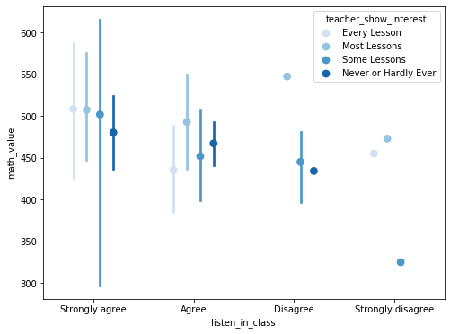

```python
fig = plt.figure(figsize = [8,6])
ax = sb.pointplot(data = sub, x = 'listen_in_class', y = 'math_value', hue = 'teacher_show_interest',
           palette = 'Blues', linestyles = '', dodge = 0.4)
```

Let's see how "teacher show interest", "listen in class" and "math interest" connected.

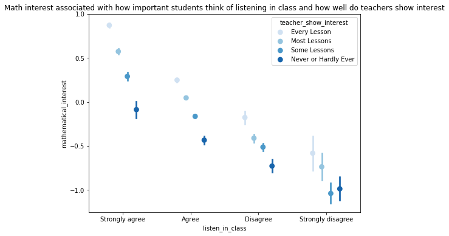

```python
fig = plt.figure(figsize = [8,6])
ax = sb.pointplot(data = sub_a, x = 'listen_in_class', y = 'mathematical_interest', hue = 'teacher_show_interest',
           palette = 'Blues', linestyles = '', dodge = 0.4)
plt.title('Math interest associated with how important students think of listening in class and how well do teachers show interest')
```

### Talk about some of the relationships you observed in this part of the investigation. Were there features that strengthened each other in terms of looking at your feature(s) of interest?

It's clear now that both listen_in_class and teacher_show_interest had influence on students' interest and math scores. However, based on the analysis in the univariate section, there is no direct relationship between mathematical interest and math scores.

### Were there any interesting or surprising interactions between features?

It's interesting the find out that some factors in the dataframe were not correlated at all, such as 'father_job_status' and "mother_job_status". It's probably because the data collection is not complete since there were no data for the choice of full_time (for pay) within job_status column. Also, wealth and computer use had little effect on math scores as well.